# Skills Analysis

By selecting the common 10 skills offered in DSAN classes and searching for them in job qualifications, we can observe the relevance and requirement of these skills across different job positions. The results provide valuable insights into how these skills are sought after in various job roles within the job market. This information can be helpful in understanding the demand for these skills and tailoring one’s skillset accordingly to align with the job requirements.

## Skills Correlation

[interactive chart not shown]

Based on the heatmap, it appears that Python is highly correlated with other skills in the job qualifications. This suggests that Python is a key skill that is commonly used in conjunction with other skills in various data science-related fields. The proficiency in Python is essential for performing tasks and analyses in data science.

## Further Look: ARM

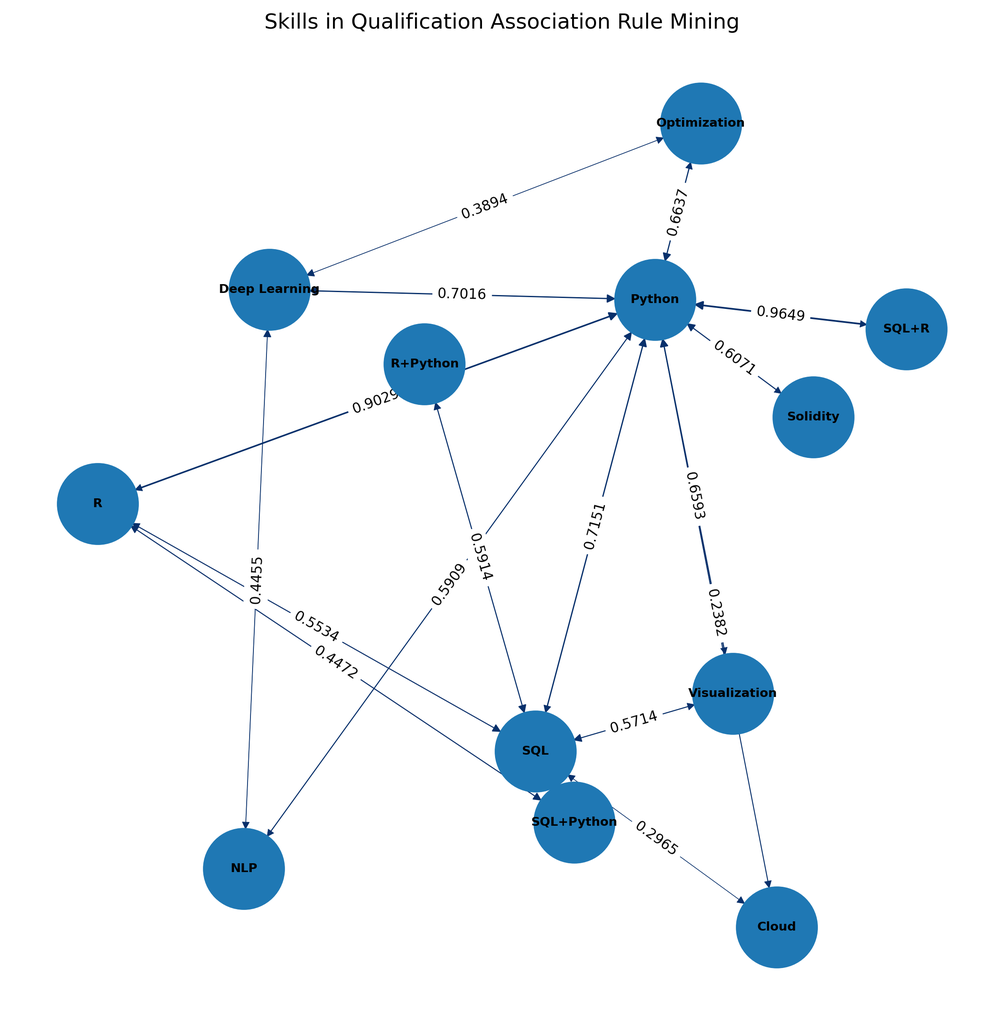

## Further Look: Skills Tracing

[interactive chart not shown]

The final graph visualizes the relationship between different skills and job types, showing how 10 specific skills are required for each job type. The lines on the graph trace the skill requirements for each job type, with Data Science and Deep Learning jobs requiring a broad range of skills, student need to learn almost all skills to fit the qualifications. In contrast, for Time Series or Blockchain jobs, students could focus on fewer skills and explore them in more depth.